# Unit 7 Pre-Live Session

MSDS 6372: Jacob Turner

## Discussion 1: IFN Data Revisited

Many repeated measures studies sample data over fixed time points. Under this setting, the time variable could be treated as a factor when the interest is to compare time points to each other. Visually, it is helpful to plot the means of each time group along with additional predictor information. For plotting purposes, it is helpful to create a data set just with summary statistics first.

The following code computes the mean IFN level for each time point and status (symptomatic and asymptomatic). Additional columns include the SE for the mean and a rough CI for each group.

```r
library(tidyverse)
setwd("/Users/Owner/git/School/DS6372_Applied_Statistics/Unit7/")
data<-read.csv(file="FluStudy.csv",stringsAsFactors = T)
#View(data)
data<-na.omit(data)

#Cleaning up variable names
names(data)[6]<-"Status"


#Summary stats by time and status
statsIFN<-data %>%
  group_by(Status,Hours) %>%
  summarise(
    count=n(),
    IFIT=mean(IFITM3),
    sdIFIT=sd(IFITM3)/sqrt(count),
    lower=IFIT-2*sdIFIT,
    upper=IFIT+2*sdIFIT
  )

statsIFN
```

```
## # A tibble: 16 × 7
## # Groups:   Status [2]
##    Status Hours count  IFIT sdIFIT lower upper
##    <fct>  <int> <int> <dbl>  <dbl> <dbl> <dbl>
##  1 Asymp      0     8  11.4  0.208  11.0  11.9
##  2 Asymp     12     8  11.3  0.183  11.0  11.7
##  3 Asymp     29     8  11.3  0.231  10.9  11.8
##  4 Asymp     45     8  11.6  0.198  11.2  12.0
##  5 Asymp     53     8  11.4  0.218  11.0  11.9
##  6 Asymp     60     8  11.6  0.338  11.0  12.3
##  7 Asymp     84     8  11.3  0.231  10.8  11.8
##  8 Asymp    108     8  11.1  0.254  10.6  11.6
##  9 Symp       0     9  11.3  0.323  10.6  11.9
## 10 Symp      12     9  11.3  0.307  10.7  11.9
## 11 Symp      29     9  11.5  0.334  10.9  12.2
## 12 Symp      45     9  12.6  0.387  11.8  13.4
## 13 Symp      53     9  13.1  0.313  12.5  13.8
## 14 Symp      60     9  13.4  0.250  12.9  13.9
## 15 Symp      84     9  13.6  0.118  13.3  13.8
## 16 Symp     108     9  13.4  0.111  13.2  13.6
```

With the mean table, we can use `ggplot` to get a sense of the trend over time by status. The second graph includes plots of individual measurements that highlight repeated measures on the same subject.

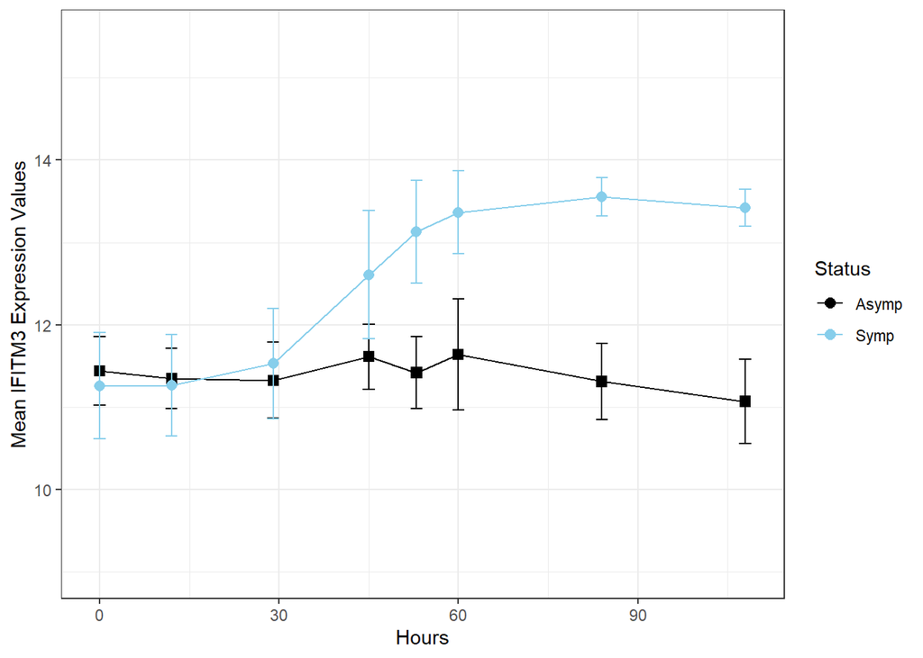

```r
library(ggplot2)
prof.mean<-ggplot(statsIFN,aes(x=Hours,y=IFIT,color=Status,shape=Status))+
  geom_line()+
  geom_point(size=2.5)+
  labs(y="Mean IFITM3 Expression Values")+
  scale_color_manual(values=c("black","skyblue"))+
  scale_shape_manual(values=c(15,16))+
  ylim(9,15.5)+
  guides(shape="none")+
  theme_bw()

prof.mean+geom_errorbar(aes(ymin=lower,ymax=upper,color=Status),width=2)
```

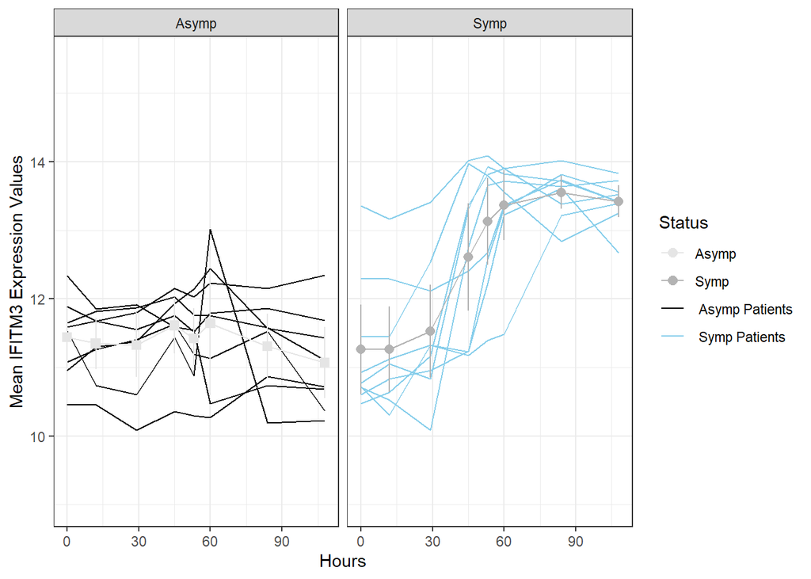

```r
ggplot(statsIFN, aes(x=Hours, y=IFIT, color=Status, shape=Status)) +
  geom_line(aes(x=Hours, y=IFITM3, group=Subject, color=" Asymp Patients"), data=data[data$Status == 'Asymp',]) +
  geom_line(aes(x=Hours, y=IFITM3, group=Subject, color=" Symp Patients"), data=data[data$Status == 'Symp',]) +
  geom_line() +
  geom_errorbar(aes(ymin = lower, ymax = upper), width = 0.5) +
  geom_point(size = 2.5) +
  labs(color="Status", x="Hours", y = "Mean IFITM3 Expression Values") +
  ylim(9, 15.5) +
  scale_color_manual(values = c("grey90", "grey70", "black", "skyblue")) +
  scale_shape_manual(values=c(15,16)) +
  guides(shape="none") +
  facet_wrap(~Status, nrow = 1) +
  theme_bw()
```

To help get a sense of the importance of repeated measures, I want you to compare the results of performing an analysis on this data set using traditional MLR (ignoring that the independence assumption is broken) versus a model that takes into account the fact that residuals are correlated. The two code chunks below provides two analyses and report some specific time comparisons as well as make residual plots. Compare the output and write a short summary of any differences in the results that exist. You will not see many, but the few that are there are important.

Repeated Measures Model

```r
library(emmeans)
library(nlme)
data$Hours.Fac<-factor(data$Hours)
UN<-gls(IFITM3~Hours.Fac*Status,data=data,correlation=corSymm(form=~1|Subject))

#Comparing changes from time point to baseline
results<-emmeans(UN,~Hours.Fac|Status,mode="df.error")
comparisons<-contrast(results, "trt.vs.ctrl",ref=1,combine = TRUE, adjust = "bonferroni",interaction=T)

#Comparing changes between status at each time point
results2<-emmeans(UN,~Status|Hours.Fac,mode="df.error")
comparisons2<-contrast(results2, "pairwise", combine = TRUE, adjust = "bonferroni")

#Aggregating results
comparisons2.update<-update(comparisons2[1]+comparisons2[2]+comparisons2[3]+comparisons2[4]+
         comparisons2[5]+comparisons2[6]+comparisons2[7]   )

comparisons
```

```
## Status = Asymp:
##  Hours.Fac_trt.vs.ctrl estimate    SE df t.ratio p.value
##  12 - 0                -0.09083 0.119 92  -0.762  1.0000
##  29 - 0                -0.11191 0.168 92  -0.666  1.0000
##  45 - 0                 0.17295 0.298 92   0.580  1.0000
##  53 - 0                -0.01926 0.333 92  -0.058  1.0000
##  60 - 0                 0.20063 0.373 92   0.537  1.0000
##  84 - 0                -0.12700 0.332 92  -0.382  1.0000
##  108 - 0               -0.36878 0.328 92  -1.126  1.0000
##
## Status = Symp:
##  Hours.Fac_trt.vs.ctrl estimate    SE df t.ratio p.value
##  12 - 0                 0.00446 0.112 92   0.040  1.0000
##  29 - 0                 0.26819 0.158 92   1.692  0.6580
##  45 - 0                 1.34953 0.281 92   4.804  <.0001
##  53 - 0                 1.87027 0.314 92   5.949  <.0001
##  60 - 0                 2.10672 0.352 92   5.986  <.0001
##  84 - 0                 2.29410 0.313 92   7.327  <.0001
##  108 - 0                2.16169 0.309 92   6.998  <.0001
##
## Degrees-of-freedom method: df.error
## P value adjustment: bonferroni method for 7 tests
```

```r
comparisons2.update
```

```
##  contrast     Hours.Fac estimate    SE df t.ratio p.value
##  Asymp - Symp 0           0.1790 0.382 92   0.469  1.0000
##  Asymp - Symp 12          0.0837 0.382 92   0.219  1.0000
##  Asymp - Symp 29         -0.2011 0.382 92  -0.526  1.0000
##  Asymp - Symp 45         -0.9976 0.382 92  -2.611  0.0737
##  Asymp - Symp 53         -1.7106 0.382 92  -4.478  0.0002
##  Asymp - Symp 60         -1.7271 0.382 92  -4.521  0.0001
##  Asymp - Symp 84         -2.2421 0.382 92  -5.869  <.0001
##
## Degrees-of-freedom method: df.error
## P value adjustment: bonferroni method for 7 tests
```

MLR Model

```r
MLR<-lm(IFITM3~Hours.Fac*Status,data=data)

#Comparing changes from time point to baseline
results<-emmeans(MLR,~Hours.Fac|Status,mode="df.error")
comparisons<-contrast(results, "trt.vs.ctrl",ref=1,combine = TRUE, adjust = "bonferroni",interaction=T)

#Comparing changes between status at each time point
results2<-emmeans(MLR,~Status|Hours.Fac,mode="df.error")
comparisons2<-contrast(results2, "pairwise", combine = TRUE, adjust = "bonferroni")

#Aggregating results
comparisons2.update<-update(comparisons2[1]+comparisons2[2]+comparisons2[3]+comparisons2[4]+
         comparisons2[5]+comparisons2[6]+comparisons2[7]   )

comparisons
```

```
## Status = Asymp:
##  Hours.Fac_trt.vs.ctrl estimate    SE  df t.ratio p.value
##  12 - 0                -0.09083 0.386 120  -0.235  1.0000
##  29 - 0                -0.11191 0.386 120  -0.290  1.0000
##  45 - 0                 0.17295 0.386 120   0.448  1.0000
##  53 - 0                -0.01926 0.386 120  -0.050  1.0000
##  60 - 0                 0.20063 0.386 120   0.519  1.0000
##  84 - 0                -0.12700 0.386 120  -0.329  1.0000
##  108 - 0               -0.36878 0.386 120  -0.954  1.0000
##
## Status = Symp:
##  Hours.Fac_trt.vs.ctrl estimate    SE  df t.ratio p.value
##  12 - 0                 0.00446 0.364 120   0.012  1.0000
##  29 - 0                 0.26819 0.364 120   0.736  1.0000
##  45 - 0                 1.34953 0.364 120   3.704  0.0023
##  53 - 0                 1.87027 0.364 120   5.133  <.0001
##  60 - 0                 2.10672 0.364 120   5.782  <.0001
##  84 - 0                 2.29410 0.364 120   6.296  <.0001
##  108 - 0                2.16169 0.364 120   5.933  <.0001
##
## P value adjustment: bonferroni method for 7 tests
```

```r
comparisons2.update
```

```
##  contrast     Hours.Fac estimate    SE  df t.ratio p.value
##  Asymp - Symp 0           0.1790 0.376 120   0.477  1.0000
##  Asymp - Symp 12          0.0837 0.376 120   0.223  1.0000
##  Asymp - Symp 29         -0.2011 0.376 120  -0.535  1.0000
##  Asymp - Symp 45         -0.9976 0.376 120  -2.656  0.0629
##  Asymp - Symp 53         -1.7106 0.376 120  -4.554  0.0001
##  Asymp - Symp 60         -1.7271 0.376 120  -4.598  0.0001
##  Asymp - Symp 84         -2.2421 0.376 120  -5.970  <.0001
##
## P value adjustment: bonferroni method for 7 tests
```

Plot of residuals are included below:

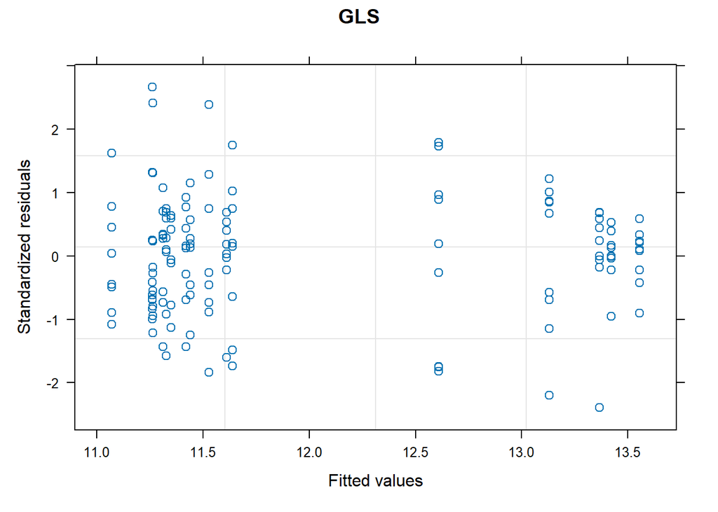

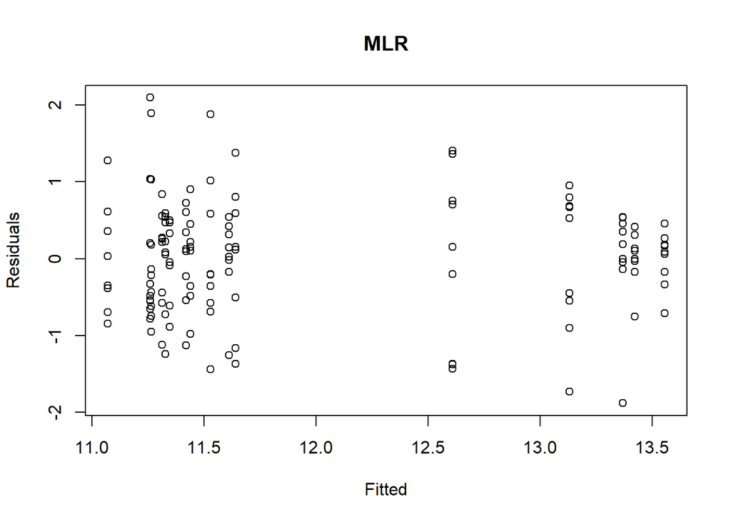

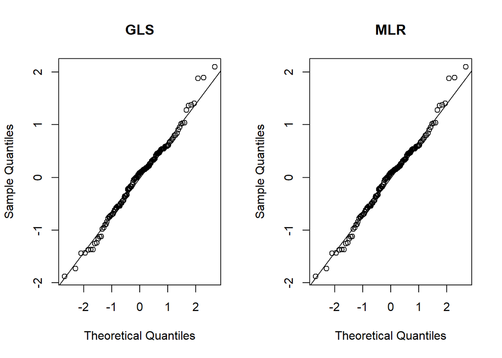

Summary:

There are not that many differences between the two models. The two that do standout are the Standard Errors and the Variation of the model’s residuals. On the GLS model output, you are able to the see the standard errors change between each point, showing that GLS does not assume that each point is independent. The MLR model assumes each data point is independent and you are able to see that it assumes that each point has the same Standard Error. On the residual vs fitted values plot, you are able to see that the GLS has a larger range than the MLR model.

## Discussion 2: A New Data Set

As mentioned during the videos, repeated measures often gets lumped into ANOVA type settings where all of the predictors are categorical. Repeated measures can exist in almost any setting a normal MLR model could be utilized. The following data set is the results of an experiment studying the weight gain of rats on different diets. It is actually available in the **nlme** package where the `gls` function lives.

```r
rats<-data.frame(BodyWeight)
head(rats)
```

```
##   weight Time Rat Diet
## 1    240    1   1    1
## 2    250    8   1    1
## 3    255   15   1    1
## 4    260   22   1    1
## 5    262   29   1    1
## 6    258   36   1    1
```

For this data set, it is expected that the weight gain (or loss) should behave in a linear way over time. The graph below provides a plot weight over time with an MLR fit for each diet group

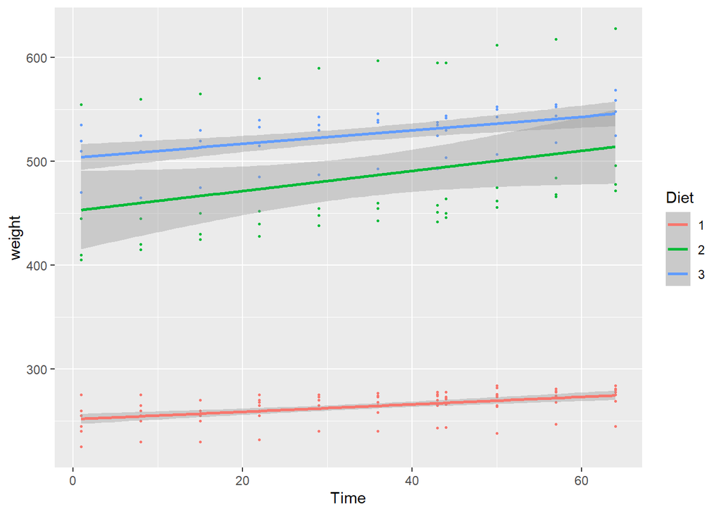

```r
ggplot(rats, aes(x=Time, y=weight,color=Diet)) +geom_point(size=.5)+
  geom_smooth(method="lm",formula="y~x")
```

1. Lets fit a regression model (MLR) including diet and time as predictors. The rates look to be potentially different so I will add an interaction term as well. Below is the result of that fit and computing a correlogram using the residuals. Comment on whether the independence of the MLR model is violated.

From the correlogram, as the time between residuals increase, the correlation starts to decrease. Indicating that the independence from the MRL is violated.

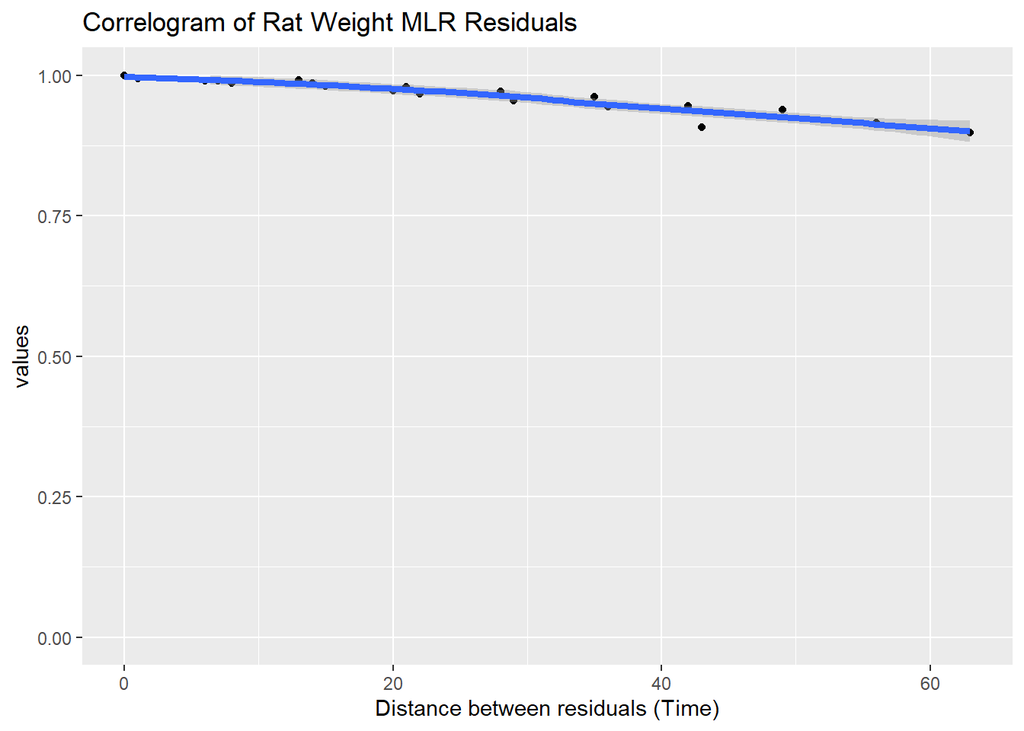

2. If the answer is yes, the assumption is violated to the previous question: what correlation structure do you think would work here (Unstructured, CS, AR)? Compare the model fits below to see if your intuition was right. Unfortunately there is not enough data to fit an unstructured model in this case.

From correlogram, I would assume that a Autoregressive structure would fit best. Since we’re measuring a datapoint where weights are closer to each other as the time between measured points are taken.

```r
#Compound Symmetry
CS<-gls(weight~Time*Diet,data=rats,correlation=corCompSymm(form=~1|Rat))

#Autoregressive
AR1<-gls(weight~Time*Diet,data=rats,correlation=corExp(form=~Time|Rat))

AIC(CS)
```

```
## [1] 1248.245
```

```r
AIC(AR1)
```

```
## [1] 1168.088
```

3. Run the same model from part B but use the traditional `lm` function and obtain a summary of the coefficients, t-stats, and p-values. Compare the two results and comment on the differences you see.

```r
rat_mlr <- lm(weight ~ Time * Diet, data =rats)

summary(rat_mlr)
```

```
##
## Call:
## lm(formula = weight ~ Time * Diet, data = rats)
##
## Residuals:
##    Min     1Q Median     3Q    Max
## -51.83 -24.22   0.66  10.44 113.89
##
## Coefficients:
##             Estimate Std. Error t value Pr(>|t|)
## (Intercept) 251.6517     7.2635  34.646   <2e-16 ***
## Time          0.3596     0.1873   1.920   0.0565 .
## Diet2       200.6655    12.5807  15.950   <2e-16 ***
## Diet3       252.0717    12.5807  20.036   <2e-16 ***
## Time:Diet2    0.6058     0.3244   1.867   0.0636 .
## Time:Diet3    0.2983     0.3244   0.920   0.3591
## ---
## Signif. codes:  0 '***' 0.001 '**' 0.01 '*' 0.05 '.' 0.1 ' ' 1
##
## Residual standard error: 34.18 on 170 degrees of freedom
## Multiple R-squared:  0.9298, Adjusted R-squared:  0.9277
## F-statistic: 450.4 on 5 and 170 DF,  p-value: < 2.2e-16
```

```r
coef(summary(AR1))
```

```
##                   Value  Std.Error   t-value      p-value
## (Intercept) 250.3364321 13.3425214 18.762303 2.850308e-43
## Time          0.3670501  0.1042628  3.520431 5.530914e-04
## Diet2       202.2653798 23.1099250  8.752317 2.008209e-15
## Diet3       257.4918656 23.1099250 11.142047 5.375365e-22
## Time:Diet2    0.6606475  0.1805885  3.658303 3.383995e-04
## Time:Diet3    0.2917069  0.1805885  1.615312 1.080974e-01
```